# Application Task 2

Shreya Shakya

06/23/2019

### Load packages

```r
library(tidyverse)
library(ggplot2)
library(dplyr)
```

### Load data

```r
pokemon <- read_csv("data/pokemon.csv")
```

### 2.1: How do Pokémon heights change after evolution?

Calculate the difference in heights pre and post evolution and save this as a new variable in the dataset. Calculate the percentage of Pokémon that grew during evolution.

**REDO : What percent of them had an increase in height?**

```r
(poke <-
pokemon %>%
  mutate(height_diff = height_new - height) %>%
  mutate(grow_percent = ((height_new - height)/(height))*100))
```

```
## # A tibble: 75 x 29
##    name  species    cp    hp weight height power_up_stardu… power_up_candy
##    <chr> <chr>   <dbl> <dbl>  <dbl>  <dbl>            <dbl>          <dbl>
##  1 Pidg… Pidgey    384    56   2.31  0.34              2500              2
##  2 Pidg… Pidgey    366    54   1.67  0.290             2500              2
##  3 Pidg… Pidgey    353    55   1.94  0.3               3000              3
##  4 Pidg… Pidgey    338    51   1.73  0.31              3000              3
##  5 Pidg… Pidgey    242    45   1.44  0.27              1900              2
##  6 Pidg… Pidgey    129    35   2.07  0.35               800              1
##  7 Pidg… Pidgey     10    10   0.92  0.25               200              1
##  8 Pidg… Pidgey     25    14   2.72  0.37               200              1
##  9 Pidg… Pidgey     24    13   2.07  0.32               200              1
## 10 Pidg… Pidgey    161    35   1.45  0.31              1000              1
## # … with 65 more rows, and 21 more variables: attack_weak <chr>,
## #   attack_weak_type <chr>, attack_weak_value <dbl>, attack_strong <chr>,
## #   attack_strong_type <chr>, attack_strong_value <dbl>, cp_new <dbl>,
## #   hp_new <dbl>, weight_new <dbl>, height_new <dbl>,
## #   power_up_stardust_new <dbl>, power_up_candy_new <dbl>,
## #   attack_weak_new <chr>, attack_weak_type_new <chr>,
## #   attack_weak_value_new <dbl>, attack_strong_new <chr>,
## #   attack_strong_type_new <chr>, attack_strong_value_new <dbl>,
## #   notes <chr>, height_diff <dbl>, grow_percent <dbl>
```

```r
#pokemon %>%
  #mutate(height_diff = height_new - height) %>%
  #mutate(grew = if(height_diff >0) height_diff) %>%
  #summarise(percent_growth = (sum(grew)/sum(height_diff))*100)

pokemon %>%
  mutate(height_diff = height_new - height) %>%
  mutate(grew = ifelse(height_diff >0,height_diff,NA)) %>%
  drop_na %>%
  summarise(percent_growth = (length(grew)/length(height_diff))*100)
```

```
## # A tibble: 1 x 1
##   percent_growth
##            <dbl>
## 1            100
```

**The percentage of Pokémon that grew during evolution is 100%.**

Visualize the distribution of change in height by species

```r
library(plyr)
```

[figure not shown]

```r
cdat <- ddply(poke,"species", summarise, height_diff.mean=mean(height_diff))

ggplot(data = poke, aes(x = height_diff,fill=species)) +
  geom_density(alpha = 0.4) +
    geom_vline(data=cdat, aes(xintercept=height_diff.mean,  colour=species),linetype="dashed", size=1)+labs(title = 'Height difference in species'
       ,y = 'Density'
       ,x = 'Height difference'
       )
```

[figure not shown]

```r
ggplot(data = poke, aes(x = height_diff,fill=species)) +
  geom_density(alpha = 0.4) +
facet_wrap(~species)  +
    geom_vline(data=cdat, aes(xintercept=height_diff.mean,  colour=species),linetype="dashed", size=1)  +
    geom_vline(data=cdat, aes(xintercept=height_diff.mean,  colour=species),linetype="dashed", size=1)+labs(title = 'Height difference by species'
       ,y = 'Density'
       ,x = 'Height difference'
       )
```

[figure not shown]

```r
ggplot(data = poke, aes(x = height_diff,fill=species)) +
  geom_histogram(position = "identity") +
    labs(title = 'Height difference in species'
       ,y = 'Density'
       ,x = 'Height difference'
       )
```

[figure not shown]

```r
ggplot(data = poke) +
  geom_histogram(mapping = aes(x = height_diff,fill=species))+
     facet_wrap(~species)  +
labs(title = 'Height difference by species'
       ,y = 'Density'
       ,x = 'Height difference'
       )
```

[figure not shown]

```r
ggplot(data = poke, aes(x = species, y=height_diff, group=species,fill=species)) +
  geom_bar(stat = "identity",position="dodge") +
  labs(title = 'Height difference in species'
       ,y = 'Height difference'
       ,x = 'species'
       )
```

How change in height varies both in general and across species?

*In general, different species have different spread for height difference. The center for height difference between each species is in a different location. The differences in the locations indicate that the mean height difference are different for all species. Weedle species tends to have lower difference in height growth whereas Pidgey tends to have higher difference in height growth among all the species. Eevee seems to vary in growth as the spread is wider, but most of the values are clustered towards the left side. Caterpie also seems to have lower difference in height growth.*

*Looking at height difference in each of the species, most values for Caterpie species are close to 0.4 and values further away are rarer. The distribution is almost symmetric and values falls between 0.3 to 0.5. For Eevee species, the long tail extends to right while most of the values are clustered to left. Pidgey species most of the values are close to 0.8 and values further away are rare. The distribution is roughly symmetric and values falls between 0.57 to 1.0. Similarly for Weedle is most of the value is at 0.3. The distribution is roughly symmetric and values falls between 0.2 to 0.42.*

### 2.2: Recreate this plot

**REDO: Used a different theme, provided a title/subtitle, and relabeled the axes and legend.**

```r
p <-poke %>%
  filter(species != c("Weedle")) %>%
  group_by(species, attack_weak) %>%
  tally() %>%
  arrange(desc(n))
p
```

```
## # A tibble: 6 x 3
## # Groups:   species [3]
##   species  attack_weak      n
##   <chr>    <chr>        <int>
## 1 Pidgey   Tackle          22
## 2 Pidgey   Quick Attack    17
## 3 Caterpie Bug Bite         5
## 4 Caterpie Tackle           5
## 5 Eevee    Tackle           4
## 6 Eevee    Quick Attack     2
```

[figure not shown]

```r
ggplot(data=p,aes(x=species, y=n, fill=attack_weak)) +
  coord_flip() +
    geom_bar(stat="identity" , position=position_dodge())+
  theme_minimal() +
    labs(title = 'Pre-evolution weaker attack of the Pokemon'
       ,y = 'Frequency'
       ,x = 'Species'
       ,subtitle = 'by species'
       ,fill='Attack weak'
       )
```

### 2.3: Do Pokémon tend to change their stronger attack post-evolution?

Calculate the relative frequency of post-evolution stronger attack based on the pre-evolution stronger attack.

**REDO: Obtain this same two-way table (i.e., round(prop.table(cross,2)) ), but using your dplyr skills**

```r
library(dplyr)
cross <- table(poke$attack_strong_new,poke$attack_strong)
round(prop.table(cross,2)*100,digits=2)
```

```
##
##               Aerial Ace Air Cutter Body Slam    Dig Struggle  Swift
##   Aerial Ace       36.36      38.46      0.00   0.00     0.00   0.00
##   Air Cutter       36.36      38.46      0.00   0.00     0.00   0.00
##   Aqua Tail         0.00       0.00     33.33   0.00     0.00 100.00
##   Fire Blast        0.00       0.00      0.00  50.00     0.00   0.00
##   Heat Wave         0.00       0.00     66.67   0.00     0.00   0.00
##   Struggle          0.00       0.00      0.00   0.00   100.00   0.00
##   Thunderbolt       0.00       0.00      0.00  50.00     0.00   0.00
##   Twister          27.27      23.08      0.00   0.00     0.00   0.00
##
##               Twister
##   Aerial Ace    46.67
##   Air Cutter    26.67
##   Aqua Tail      0.00
##   Fire Blast     0.00
##   Heat Wave      0.00
##   Struggle       0.00
##   Thunderbolt    0.00
##   Twister       26.67
```

```r
#REDO:
 pokemon %>%
  group_by(pokemon$attack_strong,pokemon$attack_strong_new) %>%
  dplyr::summarise(n=n()) %>%
  mutate(relative_freq = (n/sum(n)))
```

```
## # A tibble: 15 x 4
## # Groups:   pokemon$attack_strong [7]
##    `pokemon$attack_strong` `pokemon$attack_strong_new`     n relative_freq
##    <chr>                   <chr>                       <int>         <dbl>
##  1 Aerial Ace              Aerial Ace                      4        0.0533
##  2 Aerial Ace              Air Cutter                      4        0.0533
##  3 Aerial Ace              Twister                         3        0.04
##  4 Air Cutter              Aerial Ace                      5        0.0667
##  5 Air Cutter              Air Cutter                      5        0.0667
##  6 Air Cutter              Twister                         3        0.04
##  7 Body Slam               Aqua Tail                       1        0.0133
##  8 Body Slam               Heat Wave                       2        0.0267
##  9 Dig                     Fire Blast                      1        0.0133
## 10 Dig                     Thunderbolt                     1        0.0133
## 11 Struggle                Struggle                       30        0.4
## 12 Swift                   Aqua Tail                       1        0.0133
## 13 Twister                 Aerial Ace                      7        0.0933
## 14 Twister                 Air Cutter                      4        0.0533
## 15 Twister                 Twister                         4        0.0533
```

```r
 pokemon %>%
  group_by(attack_strong) %>%
  dplyr::count(attack_strong,attack_strong_new) %>%
  mutate(prop = round( (n / sum(n))*100,2)) %>%
  select(-n) %>%
  spread(attack_strong,prop,fill=0)
```

```
## # A tibble: 8 x 8
##   attack_strong_n… `Aerial Ace` `Air Cutter` `Body Slam`   Dig Struggle
##   <chr>                   <dbl>        <dbl>       <dbl> <dbl>    <dbl>
## 1 Aerial Ace               5.33         6.67        0     0           0
## 2 Air Cutter               5.33         6.67        0     0           0
## 3 Aqua Tail                0            0           1.33  0           0
## 4 Fire Blast               0            0           0     1.33        0
## 5 Heat Wave                0            0           2.67  0           0
## 6 Struggle                 0            0           0     0          40
## 7 Thunderbolt              0            0           0     1.33        0
## 8 Twister                  4            4           0     0           0
## # … with 2 more variables: Swift <dbl>, Twister <dbl>
```

*The above graph shows the table for each pre-evo attack, the percentage breakdown of each post-Evo attack. Each column represents the pre evolution attack and each observation represents the post evolution attack.*

*For pre-evo attack Aerial Ace air, the percentage breakdown of its post evolution attack is 36.36%, 36.36% and 27.27% on Aerial Ace, Air Cutter and Twister respectively.*

*For pre-evo attack Cutter Body, the percentage breakdown of its post evolution attack is 38.46%, 38.46% and 23.08% on Aerial Ace, Air Cutter and Twister respectively.*

*For pre-evo attack Dig, the percentage breakdown of its post evolution attack is 50% and 50% on Fire Blast and Thunderbolt respectively.*

*For pre-evo attack Struggle, the percentage breakdown of its post evolution attack is 100% on Struggle itself.*

*For pre-evo attack Swift, the percentage breakdown of its post evolution attack is 100% on Aqua Tail respectively.*

### 2.4: Relationship between categorical variables

Pick two categorical variables and construct a plot that depicts the relationship between them.

**REDO: Provided a title/subtitle, and relabeled the axes**

[figure not shown]

```r
ggplot(poke, aes(x=attack_strong_type,y =attack_strong_value)) + geom_bar(aes(fill = attack_strong), stat = "identity", position = "dodge") +
    theme_minimal() +
    labs(title = 'Pre-evolution Attack strong of the Pokemon by attack strong value'
       ,y = 'Frequency'
       ,x = 'Species'
       ,subtitle = 'by species'
       )
```

```r
#+facet_wrap(~species)
```

*Here, attack strong value for several different attack strong type are graphed. Within each original category i.e attack strong type, the data is categorized further based on a second categorical variable attack_strong. These “attack_strong” categories are created within each of the four “attack strong type” categories, and each of the seven categories-within-a-category has its own bar. While the original categories are distinguished using the original labeling system along the x-axis, the second categorical variable is determined using a color scheme.*

### 2.5: Comparative boxplots

Pick a numerical and a categorical variable and construct a side-by-side boxplot depicting their relationship.

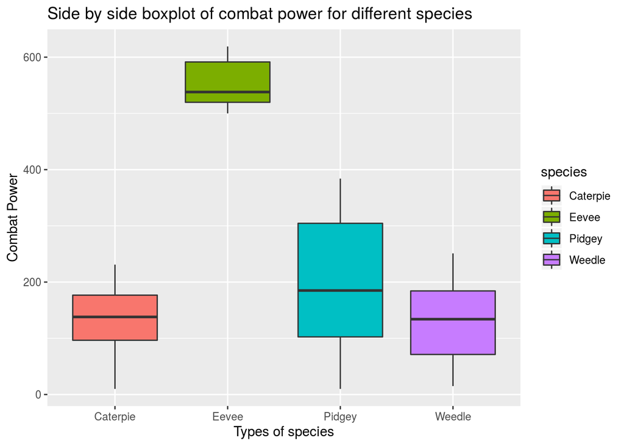

```r
ggplot(poke, aes(species,cp,fill=species))+
  geom_boxplot()+
    labs(title = 'Side by side boxplot of combat power for different species'
       ,y = 'Combat Power'
       ,x = 'Types of species'
       )
```

### 2.6: Violin plots

What do the violin plots reveal that the boxplots do not? What features are apparent in the boxplots, but not in the violin plots?

**REDO: Provided a title/subtitle, and relabeled the axes**

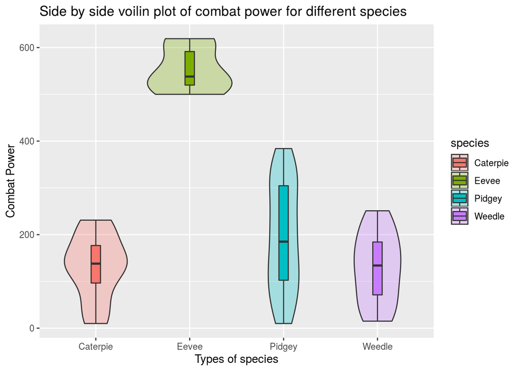

```r
 ggplot(poke, aes(species,cp,fill=species))+
  geom_violin(alpha=0.3) +
  geom_boxplot(width=0.1) +
    labs(title = 'Side by side voilin plot of combat power for different species'
       ,y = 'Combat Power'
       ,x = 'Types of species'
       )
```

*Similar to boxplot, Voilin plots can also be used to show the relationship between species and their pre evolution combat power. From above graph, we can see that these plots are more informative compared to previous boxplot. Box plot can only be used to show the summary statistics such as mean, median, interquartile ranges. Whereas, voilin plots can show these summary statistics along with the distribution of the data.*

### 2.7: Characteristics of an evolved Pokémon combat power

What characteristics correspond to an evolved Pokémon with a high combat power? You do not need to come up with an exhaustive list, but you should walk through your reasoning as you answer this question. Include all relevant summary statistics and visualizations.

**REDO: Using more descriptive variable names (rather than the data set names). Also, added labels/titles in the plots.**

*The evolved pokemon with high combat power could be analyzed by looking at the correlation between each of the variable*

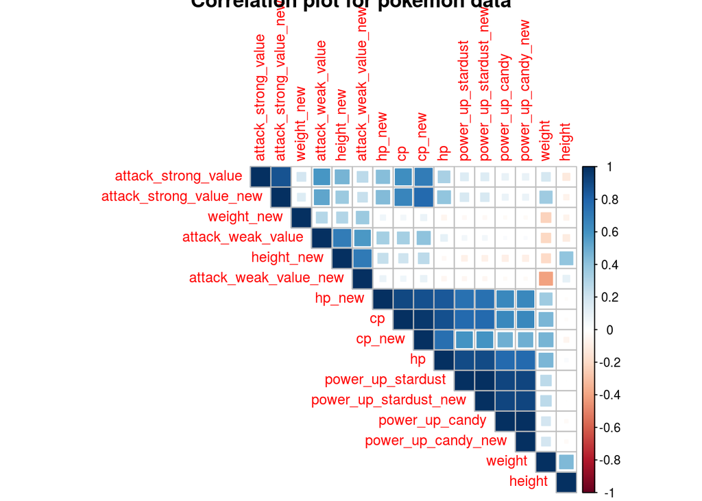

```r
library(corrplot)
library(corrr)
data <- pokemon[, sapply(pokemon, is.numeric)]

M <- cor(data,use="pairwise.complete.obs")
c2 <- corrplot(M,type = "upper",order = "hclust", title="Correlation plot for pokemon data", method = "square", tl.cex = 0.85, cl.cex = 0.75)
```

```r
data %>% correlate(use="pairwise.complete.obs") %>% focus(cp) %>% data.frame()
```

```
##
## Correlation method: 'pearson'
## Missing treated using: 'pairwise.complete.obs'
```

```
##                    rowname          cp
## 1                       hp  0.87607609
## 2                   weight  0.45483415
## 3                   height -0.01717795
## 4        power_up_stardust  0.77385620
## 5           power_up_candy  0.64479192
## 6        attack_weak_value  0.33527977
## 7      attack_strong_value  0.61326426
## 8                   cp_new  0.96101924
## 9                   hp_new  0.90764010
## 10              weight_new  0.05786113
## 11              height_new  0.20066976
## 12   power_up_stardust_new  0.77385620
## 13      power_up_candy_new  0.64479192
## 14   attack_weak_value_new  0.06568735
## 15 attack_strong_value_new  0.65424077
```

```
##
## Correlation method: 'pearson'
## Missing treated using: 'pairwise.complete.obs'
```

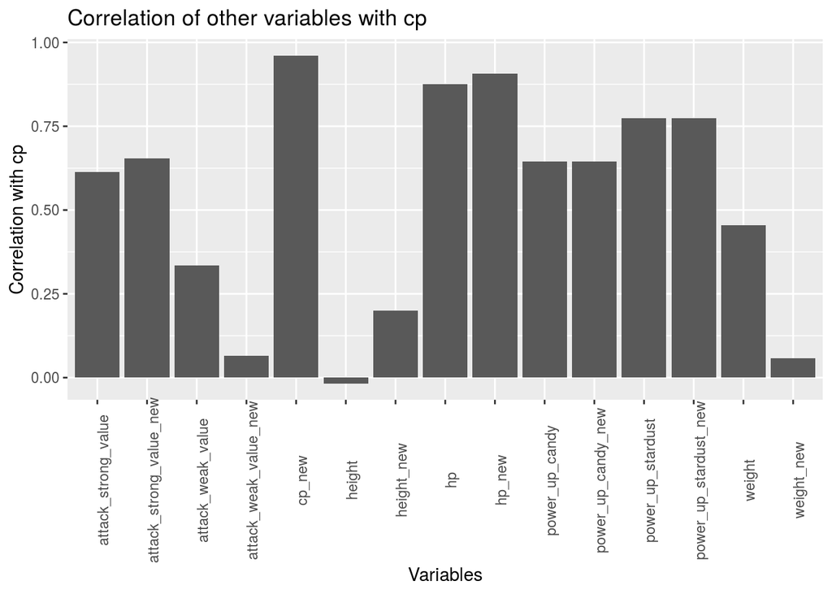

```r
data %>% correlate() %>% focus(cp) %>%
  ggplot(aes(x = rowname, y = cp)) +
    geom_bar(stat = "identity") +
  theme(axis.text.x=element_text(angle=90,margin = margin(-0.15, unit = "cm"),vjust =1))+
      labs(title = 'Correlation of other variables with cp'
       ,y = 'Correlation with cp'
       ,x = 'Variables'
       )
```

**From the above analysis we can conclude that mostly pokemon’s strength for battling (CP) is highly impacted by how difficult it is to weaken the pokemon in the battle for both pre-evolution and post-evolution pokemons. Pokemon’s strength for battling is also related to both prevolution and post-evolution stardust required to power up pokemon. As the difficulty to weaken the pokemon increases so does the pokemon’s strength in battling increases. It has positive correlation of 0.88 (pre) and 0.91 (post). Similarly, for power_up_stardust (old and new) postive correlation of 0.77. These variables are explored more below.**

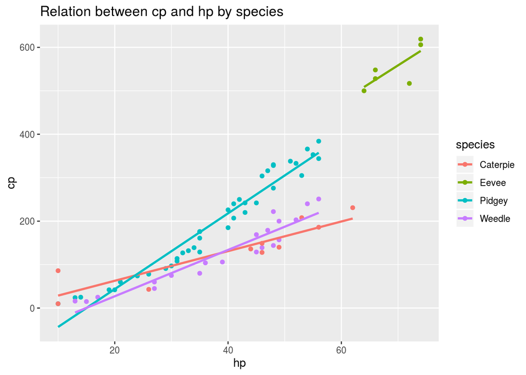

```r
library("dplyr")
ggplot(data = poke, aes(x = hp, y = cp, color=species)) +
  geom_point() +
  geom_smooth(method = "lm", se = FALSE)  +
        labs(title = 'Relation between cp and hp by species'
       ,y = 'cp'
       ,x = 'hp'
       )
```

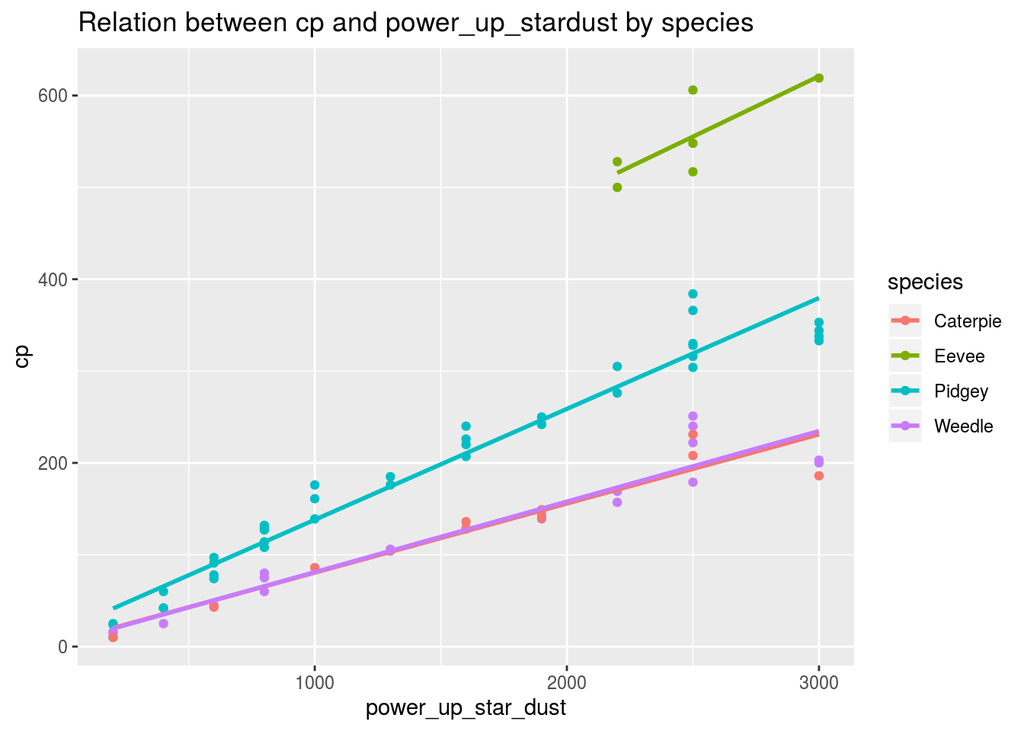

```r
ggplot(data = poke, aes(x = power_up_stardust, y = cp, color=species)) +
  geom_point() +
  geom_smooth(method = "lm", se = FALSE) +
          labs(title = 'Relation between cp and power_up_stardust by species'
       ,y = 'cp'
       ,x = 'power_up_star_dust'
       )
```

*For all the species, we can see that as the difficulty to weaken the pokemon increases increases, pokemon’s strength in battling tends to increase postively. Similarly as the power_up_stardust increases, pokemon’s strength in battling also tends to increase positively. Therefore, we can conclude that evolved Pokémon with a high combat power highly depends on how difficult it is to weaken the pokemon and stardust required to power up the Pokemon.*